# Incidence, prevalence, and predictors of treatment‐resistant hypertension with intensive blood pressure lowering - Smith - 2019 - The Journal of Clinical Hypertension - Wiley Online Library

[The Journal of Clinical Hypertension](https://onlinelibrary.wiley.com/journal/17517176)

[Volume 21, Issue 6](https://onlinelibrary.wiley.com/toc/17517176/2019/21/6) p. 825-834

ORIGINAL PAPER

Free Access

# Incidence, prevalence, and predictors of treatment-resistant hypertension with intensive blood pressure lowering

[Steven M. Smith PharmD, MPH](https://onlinelibrary.wiley.com/action/doSearch?ContribAuthorRaw=Smith%2C+Steven+M),

[Matthew J. Gurka PhD](https://onlinelibrary.wiley.com/action/doSearch?ContribAuthorRaw=Gurka%2C+Matthew+J),

[Almut G. Winterstein PhD](https://onlinelibrary.wiley.com/action/doSearch?ContribAuthorRaw=Winterstein%2C+Almut+G),

[Carl J. Pepine MD](https://onlinelibrary.wiley.com/action/doSearch?ContribAuthorRaw=Pepine%2C+Carl+J),

[Rhonda M. Cooper-DeHoff PharmD, MS](https://onlinelibrary.wiley.com/action/doSearch?ContribAuthorRaw=Cooper-DeHoff%2C+Rhonda+M),

First published: 07 May 2019

https://doi.org/10.1111/jch.13550

Citations: 8

**Trial Registrations:** SPRINT (ClinicalTrials.gov number, NCT01206062); ACCORD-BP (ClinicalTrials.gov number, NCT00000620)

**Funding information**

Dr Smith is funded by the National Heart, Lung, and Blood Institute (K01 HL138172). Dr Pepine is also funded by the National Heart, Lung, and Blood Institute (R01 HL132448 and R01 HL033610).

## Abstract

Recent guidelines call for more intensive blood pressure (BP)-lowering and a less-stringent treatment-resistant hypertension (TRH) definition, both of which may increase the occurrence of this high-risk phenotype. We performed a post hoc analysis of 11 784 SPRINT and ACCORD-BP participants without baseline TRH, who were randomized to an intensive (<120 mm Hg) or standard (<140 mm Hg) systolic BP target. Incidence, prevalence, and predictors of TRH were compared using the updated definition (requiring ≥4 drugs to achieve BP < 130/80 mm Hg) during intensive treatment, vs the former definition (requiring ≥4 drugs to achieve BP < 140/90 mm Hg) during standard treatment. Incidence/prevalence of apparent refractory hypertension (RFH; uncontrolled BP despite ≥5 drugs) was similarly compared. Overall, 5702 and 6082 patients were included in the intensive and standard treatment cohorts, respectively. Crude TRH incidence using the updated definition under intensive treatment was 30.3 (95% CI, 29.3-31.4) per 100 patient-years, compared with 9.7 (95% CI, 9.2-10.2) using the prior definition under standard treatment. Point prevalence using the prior TRH definition at 1-year was 7.5% in SPRINT and 14% in ACCORD vs 22% and 36%, respectively, with the updated TRH definition. Significant predictors of incident TRH included number of baseline antihypertensive drugs, having diabetes, baseline systolic BP, and Black race. Incidence of apparent RFH was also significantly greater using the updated vs prior definition (4.5 vs 1.0 per 100 person-years). Implementation of the 2017 hypertension guideline, including lower BP goals for most individuals, is expected to substantially increase treatment burden and incident TRH among the hypertensive population.

## 1 INTRODUCTION

Cases of difficult-to-control blood pressure (BP) despite treatment with multi-drug regimens—so called “treatment-resistant hypertension” (TRH)—have been recognized for over half a century. This phenotype is known to portend worse outcomes, both in terms of higher risk of adverse cardiovascular outcomes including death,1-3 and diminished health-related quality of life, compared to non-resistant hypertension.4 In the 1970s, TRH was considered to be rare and diminishing,5 particularly at a time when increasingly effective and safer antihypertensive agents were entering the market. However, research over the last decade has shown that, far from being rare, TRH appears to be present in a sizeable proportion of the overall treated hypertensive population. For example, a recent meta-analysis of observational and interventional studies suggests an overall TRH prevalence between 11% and 21% of patients with treated hypertension.6 Furthermore, data from the National Health and Nutrition Examination Survey (NHANES) suggest the prevalence of TRH has more than doubled over the past 25 years.7

## 2 METHODS

Details of the design and principal findings of SPRINT11, 12 and ACCORD-BP13, 14 have been published. Briefly, SPRINT was a prospective, randomized, open-label, blinded-endpoint (PROBE) design trial enrolling hypertensive individuals with elevated cardiovascular (CV) risk from across the US, with random assignment to a systolic BP target < 120 mm Hg (“intensive”) or <140 mm Hg (“standard”). Participants were aged ≥50 years, with a baseline systolic BP 130 to 180 mm Hg, and ≥1 additional CV risk factor (see Supplement for detailed eligibility criteria). Major exclusion criteria were diabetes or prior stroke. Due to superior benefits of intensive treatment, SPRINT was stopped early.11

ACCORD-BP was a PROBE design trial, enrolling patients with type 2 diabetes mellitus, an A1c ≥ 7.5%, age ≥40 years with CV disease or ≥55 years without CV disease, and evidence of elevated CV risk (see additional detail in Supplement). Patients were also required to have a baseline systolic BP between 130 and 180 mm Hg. Major exclusion criteria were BMI ≥ 45 kg/m<sup>2</sup>, serum creatinine ≥1.5 mg/dL, 24-hour protein excretion rate ≥1.0 g, ≥2+ on dipstick protein in a spot urine test, ≥700 mg/g protein/creatinine ratio in a spot urine test, or other serious illness.

### 2.1 Cohort assembly and outcome ascertainment

Patient-level data from both trials were acquired from the National Heart, Lung, and Blood Institute pursuant to a data use agreement after local Institutional Review Board approval. Complete data were available from ACCORD-BP, whereas only baseline measures, follow-up BP and antihypertensive use (number only, not specific drugs/classes), and outcomes were available from SPRINT.

Data from both trials were pooled, with an indicator for original study, and harmonized. Patients were divided into two cohorts according to random treatment assignment (systolic BP target < 140 mm Hg [standard] or <120 mm Hg [intensive]) and categorized according to TRH status at baseline using treatment arm-specific definitions. For patients assigned the intensive systolic BP target, TRH (referred to hereafter as TRH<sub>updated</sub>) was defined per the 2017 ACC/AHA hypertension guidelines9 as use of ≥3 antihypertensive drugs with systolic BP ≥ 130 or diastolic BP ≥ 80 mm Hg, or use of ≥4 antihypertensive drugs regardless of BP. For patients assigned to the standard systolic BP target, TRH (referred to hereafter as TRH<sub>prior</sub>) was defined per the 2008 AHA TRH scientific statement8 as use of ≥3 antihypertensive drugs with a systolic BP ≥ 140 or diastolic BP ≥ 90 mm Hg, or use of ≥4 antihypertensive drugs regardless of BP. Additional details regarding the rationale and operationalization of these definitions are contained in the Supplement. A thiazide diuretic was not required for either definition in the primary analysis because data on specific antihypertensive drug use were not available from SPRINT. However, inclusion of a diuretic was considered in sensitivity analyses using ACCORD-BP data only. We also performed sensitivity analyses using a more conservative TRH<sub>updated</sub> definition that considered individuals with controlled systolic BP (<130 mm Hg) while taking 4 antihypertensive drugs as not having TRH, because some of these patients were titrated to the fourth drug per trial protocols even though they would not meet the 2017 hypertension guideline definition for TRH. Patients meeting, at baseline, the definition of TRH<sub>updated</sub> (intensive arm) or TRH<sub>prior</sub> (standard arm) were excluded from primary analyses. We then categorized patient-level TRH status at each follow-up visit, using the aforementioned cohort-specific definitions.

We also compared occurrence of apparent refractory hypertension (RFH), using a definition modified from the 2017 hypertension guidelines,9 as uncontrolled BP despite use of ≥5 antihypertensive drugs, where uncontrolled BP was defined as ≥130/80 mm Hg for the intensive group (RFH<sub>updated</sub>) and ≥140/90 mm Hg for the standard group (RFH<sub>prior</sub>). Neither aldosterone antagonists nor thiazide diuretic use were required for these definitions because the ACCORD dataset did not explicitly record aldosterone antagonist use, and available SPRINT data did not include patient-level data on specific drugs used.

For assessment of incidence, we identified first occurrence of the outcome (eg, TRH, RFH). For those developing an outcome, timing of the event was determined by the timing of the first visit at which the patient met criteria because actual visit dates were unavailable. For example, a patient first meeting TRH criteria at the 12-month visit was assumed to have developed TRH at exactly 12 months, although the 12-month study visit could have occurred within a pre-specified window around 12 months after randomization. Follow-up in those not developing an outcome was censored at the time of the last visit at which BP and antihypertensive medication log data were available. The main comparison of interest was incidence (first occurrence) of TRH<sub>updated</sub> under intensive systolic BP-lowering vs TRH<sub>prior</sub> under standard systolic BP-lowering. To account for potential variation in TRH status over time, we also assessed incidence of persistent TRH, defined as first occurrence of 2 and 3 consecutive visits with TRH, in sensitivity analyses. We also compared point prevalence of TRH<sub>updated</sub> and TRH<sub>prior</sub>, as well as RFH<sub>updated</sub> and RFH<sub>prior</sub> at each protocol-mandated visit. Sensitivity analysis was performed on TRH point prevalence by including individuals with baseline TRH. Patients with baseline RFH were largely excluded from both trials; thus, no similar sensitivity analysis was performed on RFH.

Because nonadherence is thought to be a significant contributor to pseudoresistance, we performed sensitivity analyses for TRH incidence and point prevalence that incorporated self-reported medication adherence data from ACCORD-BP (adherence unavailable in SPRINT data). These sensitivity analyses operationalized the TRH definitions as above, but with the additional requirement that adherence for each drug be documented in the medication log as “All or almost all (≥80% of the time),” or “Greater than prescribed (>100% of the time).”

### 2.2 Statistical analysis

Crude incidence rates and 95% confidence intervals (CIs) were calculated via Poisson regression and expressed per 100 patient-years. Cumulative incidence curves were created for each outcome. Point prevalences were calculated by dividing the total number of patients meeting TRH (or RFH) criteria by the total number of patients with BP and antihypertensive medication use data at each visit. Because visit timing differed between trials, point prevalence data were calculated separately for each trial.

To identify predictors of incident TRH, Cox proportional hazards models were fit for each treatment cohort separately. Models accounting for all-cause death (via censoring) as a competing risk did not appreciably alter results; thus, the final models did not consider death as a competing risk for simplicity. Study cohort (SPRINT vs ACCORD; also, a proxy for no history of diabetes [SPRINT] or history of diabetes [ACCORD] based on original study inclusion/exclusion criteria) was included as an independent variable in both models. We also examined the following covariates using backward elimination and requiring *P* < 0.1 to stay in the model: age, sex, race/ethnicity, baseline statin use, baseline aspirin use, history of clinical CV disease, smoking status, baseline systolic BP, baseline diastolic BP, Framingham 10-year cardiovascular risk score, body mass index (BMI), baseline estimated glomerular filtration rate (eGFR), baseline glucose, and assignment to an intensive glycemia vs standard glycemia arm; for the latter, all SPRINT patients were considered as receiving standard glycemia treatment. Pairwise interactions between age, sex, and race were also explored. For all models, ties were handled with the Efron method. All analyses were performed using SAS 9.4 (SAS Institute, Cary, NC, USA).

## 3 RESULTS

A total of 14 094 patients were included in the pooled cohort: 9361 from SPRINT and 4733 from ACCORD-BP. After exclusion of those with TRH at baseline (n = 2310), 5702 patients remained in the intensive treatment cohort and 6082 in the standard treatment cohort (Figure 1). The modest imbalance in sample size between the treatment cohorts was due to the less restrictive TRH<sub>prior</sub> definition in the standard treatment cohort, resulting in fewer exclusions for baseline TRH in this group. Pertinent baseline characteristics of each treatment cohort are summarized in Table 1. In general, the cohorts were similar, consistent with randomization employed in both trials. Baseline characteristics of excluded patients are summarized in Table S1.

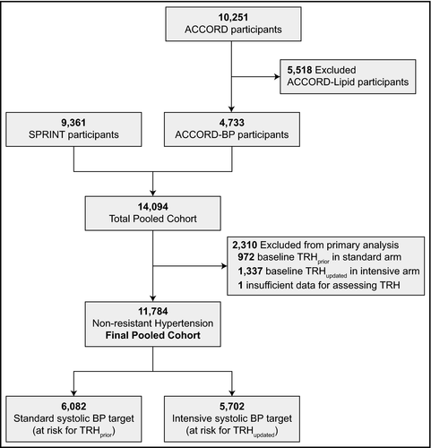

**Figure 1**

Flow diagram for cohort assembly for primary analysis. ACCORD, Action to Control Cardiovascular Risk in Diabetes; BP, blood pressure; SPRINT, Systolic Blood Pressure Intervention Trial; TRH, treatment-resistant hypertension

Table 1. Baseline characteristics, by random treatment assignment, among patients with non-resistant hypertension at baseline

| Characteristic | Intensive (n = 5702) | Standard (n = 6082) |
| --- | --- | --- |
| Study |  |  |
| SPRINT | 3682 (64.6%) | 3953 (65.0%) |
| ACCORD-BP | 2020 (35.4%) | 2129 (35.0%) |
| Intensive glycemia arma | 1020 (50.5%) | 1087 (51.1%) |
| Age | 65.9 ± 8.8 | 65.9 ± 8.9 |
| Female sex | 2247 (39.4%) | 2365 (38.9%) |
| Race/Ethnicity |  |  |
| White | 3401 (59.7%) | 3554 (58.4%) |
| Black | 1458 (25.6%) | 1644 (27.0%) |
| Other | 304 (5.3%) | 300 (4.9%) |
| Hispanic | 539 (9.5%) | 584 (9.6%) |
| History of clinical CVD | 1232 (21.6%) | 1313 (21.6%) |
| Framingham risk score, % | 38.9% ± 25.4% | 38.4% ± 25.1% |
| Smoking status |  |  |
| Never | 2519 (44.2%) | 2692 (44.3%) |
| Past | 2363 (41.5%) | 2577 (42.4%) |
| Current | 552 (9.7%) | 529 (8.7%) |
| Unknown | 264 (4.6%) | 280 (4.6%) |
| Statin Use | 2767 (48.8%) | 3081 (51.0%) |
| Aspirin Use | 2896 (51.0%) | 2982 (49.3%) |
| Number of antihypertensives |  |  |
| 0 drugs | 981 (17.2%) | 1006 (16.5%) |
| 1 drug | 2079 (36.5%) | 2089 (34.4%) |
| 2 drugs | 2325 (40.8%) | 2303 (37.9%) |
| 3 drugs | 317 (5.6%) | 684 (11.3%) |
| Mean ± SD | 1.35 ± 0.83 | 1.44 ± 0.90 |
| Laboratory values |  |  |
| TC, mg/dL | 193 ± 43 | 191 ± 43 |
| HDL, mg/dL | 51 ± 14 | 51 ± 15 |
| LDL, mg/dL | 113 ± 37 | 112 ± 36 |
| Triglycerides, mg/dL | 149 ± 131 | 150 ± 141 |
| Glucose, mg/dL | 126 ± 52 | 125 ± 51 |
| eGFR, mL/min | 80 ± 26 | 80 ± 25 |
| UACR, mg/g | 54 ± 216 | 53 ± 233 |
| SCr, mg/dL | 0.99 ± 0.31 | 1.00 ± 0.30 |
| Baseline BP |  |  |
| Systolic, mm Hg | 139 ± 16 | 138 ± 15 |
| Diastolic, mm Hg | 77 ± 11 | 77 ± 11 |
| BMI, kg/m<sup>2</sup> | 30.4 ± 5.8 | 30.5 ± 5.7 |

### Note

- Data represent mean ± SD or No. (%).
- Abbreviations: BMI, body mass index; BP, blood pressure; CVD, cardiovascular disease; eGFR, estimated; glomerular filtration rate; HDL, high-density lipoprotein; LDL, low-density lipoprotein; SCr, serum creatinine; TC, total cholesterol; UACR, urinary albumin-to-creatinine ratio.
- <sup>*a*</sup> Row percentages calculated using ACCORD-BP sample sizes (row directly above) as the denominator.

### 3.1 Incidence

Among patients assigned to the intensive systolic BP goal, 3256 (57.1%) developed TRH<sub>updated</sub> during 10 740 patient-years of follow-up, for an overall crude incidence rate of 30.3 (95% CI, 29.3-31.4) per 100 patient-years. Among patients assigned to the standard systolic BP goal, 1653 (27.2%) developed TRH<sub>prior</sub> over 17 052 patient-years, for an overall crude incidence rate of 9.7 (95% CI, 9.2-10.2) per 100 patient-years. Figure 2 displays cumulative incidence curves for each TRH definition. TRH incidence was higher among ACCORD-BP compared with SPRINT participants (Figure S1). Sensitivity analyses considering individuals with controlled BP while taking 4 antihypertensives as not having TRH revealed only a modest reduction in incidence of TRH<sub>updated</sub> (27.9 per 100 patient-years; 95% CI, 27.0-28.9). Likewise, sensitivity analyses incorporating adherence into the TRH definitions revealed only modestly lower incidences (Figure S2). As shown in Figure S3, the incidence of persistent TRH (ie, requiring a patient to meet TRH criteria over consecutive visits) was lower, with both definitions, compared with the primary analysis (ie, requiring only a single visit where TRH criteria were met). However, incidence rate ratios (comparing incidence of TRH<sub>updated</sub> to TRH<sub>prior</sub>) were modestly increased with persistent TRH definitions compared with the primary analysis, suggesting that the greater incidence of TRH<sub>updated</sub> was not markedly influenced by single visits meeting TRH criteria.

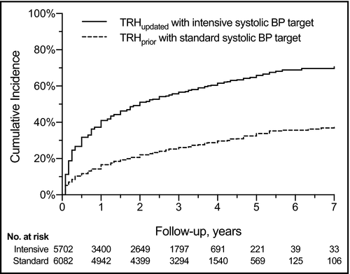

**Figure 2**

Cumulative incidence of treatment-resistant hypertension when targeting an intensive systolic vs standard systolic blood pressure. BP, blood pressure; TRH, treatment-resistant hypertension

The incidence of TRH, regardless of the definition/treatment assignment, was associated with number of antihypertensive agents used at enrollment (Figure 3). Among those randomly assigned to the intensive systolic BP goal, TRH<sub>updated</sub> incidence was approximately 20 per 100 patient-years, whether treated with 0 or 1 antihypertensive drugs at baseline. In contrast, among persons taking 3 antihypertensive drugs at baseline who were assigned to intensive systolic BP goal, the TRH<sub>updated</sub> incidence rate was 85.1 (95% CI, 75.4-96.0) per 100 patient-years. Similar trends were observed with TRH<sub>prior</sub>.

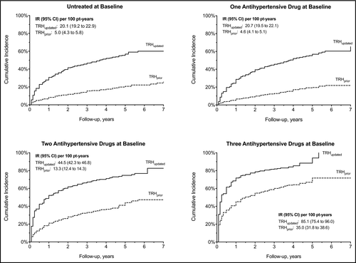

**Figure 3**

Treatment-resistant hypertension incidence stratified by number of antihypertensive agents prescribed at trial baseline. IR, incidence rate; TRH, treatment-resistant hypertension

Incident RFH was considerably less common, compared with incident TRH. Cumulative incidence curves for apparent RFH are displayed in Figure 4. During a total of 22 094 person-years, 997 individuals in the intensive arm met RFH<sub>updated</sub> criteria, for a crude incidence rate of 4.5 (95% CI, 4.2-4.8) per 100 person-years. Among those assigned to the standard arm, 231 met RFH<sub>prior</sub> criteria during a total of 24 112 person-years, for a crude incidence rate of 1.0 (95% CI, 0.8-1.1) per 100 person-years.

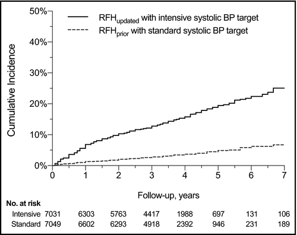

**Figure 4**

Cumulative incidence of apparent refractory hypertension, comparing definitions incorporating the updated blood pressure goal vs the prior blood pressure goal. Refractory hypertension was defined as uncontrolled blood pressure despite use of ≥5 antihypertensive drugs, where uncontrolled was defined as ≥130 mm Hg systolic or ≥80 mm Hg diastolic (RFH<sub>updated</sub>), or ≥140 mm Hg systolic or ≥90 mm Hg diastolic (RFH<sub>prior</sub>). RFH, refractory hypertension

### 3.2 Point prevalence

Point prevalence of TRH during follow-up, according to study (SPRINT vs ACCORD-BP), is summarized in Figure 5. At year 1, 22% of SPRINT and 36% of ACCORD-BP participants assigned to an intensive systolic BP target were classified as having TRH<sub>updated</sub>. By year 4, the prevalence had modestly increased to 26% and 48%, respectively. In contrast, with a standard systolic BP target, the prevalence of TRH<sub>prior</sub> at year 1 was 7.5% in SPRINT and 14% in ACCORD-BP. Thereafter, TRH<sub>prior</sub> prevalence was essentially unchanged in SPRINT and increased only modestly in ACCORD-BP (17% at year 4; 25% at year 7). Sensitivity analyses using ACCORD-BP data only, and requiring minimum adherence levels or a diuretic in the definitions of TRH, revealed qualitatively similar findings (Figure S4). Similarly, sensitivity analyses using an alternative data source for medication use data in ACCORD-BP (see Supplement for additional details) revealed similar findings (data not shown). Inclusion of patients with TRH at baseline caused a modest upward shift in point prevalence estimates (Figure S5).

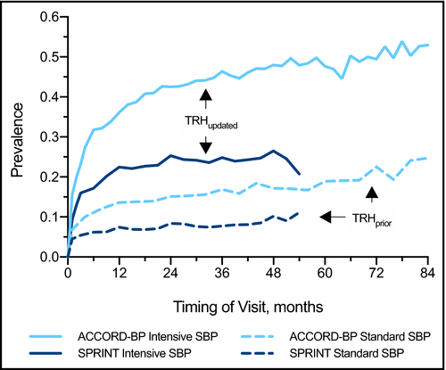

**Figure 5**

Point prevalence for treatment-resistant hypertension, by definition, study, and treatment cohort, during follow-up. SBP, systolic blood pressure, TRH, treatment-resistant hypertension

Similar to TRH prevalence, RFH prevalence was greater among ACCORD-BP than SPRINT participants. At year 1, 2.2% of SPRINT participants and 5.3% of ACCORD-BP participants met RFH<sub>updated</sub> criteria, compared with 0.4% and 1.2%, respectively, meeting RFH<sub>prior</sub> criteria. Thereafter, prevalences for both RFH definitions remained essentially unchanged in SPRINT and increased only modestly in ACCORD-BP (Figure S6).

### 3.3 Predictors of incident treatment-resistant hypertension

Table 2 summarizes results of the full models assessing predictors of incident TRH in each cohort. The predictors of incident TRH, regardless of the definition or cohort, were number of baseline antihypertensive agents, being an ACCORD-BP participant (also an indicator for having diabetes), baseline systolic BP, and Black race. Significant predictors were largely similar for each definition of TRH, except that female sex portended an 18% lower risk of developing TRH<sub>updated</sub>, whereas sex was not a significant predictor for TRH<sub>prior</sub>, and history of clinical cardiovascular disease was associated with a 20% greater risk of incident TRH<sub>prior</sub>, but had no association with TRH<sub>updated</sub>. However, confidence intervals for each risk factor comparison between the two TRH definitions overlapped and observed differences may be an artifact of statistical imprecision. In exploratory analyses, we also observed a significant interaction between sex and age on predicting TRH<sub>updated</sub>, such that female sex was highly protective against incident TRH<sub>updated</sub> at younger ages, but not older ages (Figure S7).

Table 2. Hazard ratios and 95% confidence intervals from full models assessing predictors of incident treatment-resistant hypertension, by treatment cohort

| Parameters | Intensive systolic BP cohort | Standard systolic BP cohort |
| --- | --- | --- |
| Dependent variable | TRH<sub>updated</sub> | TRH<sub>prior</sub> |
| Independent variablesa |  |  |
| ACCORD-BP participant | 1.60 (1.43-1.79) | 1.21 (1.03-1.41) |
| Age (per decade) | 0.99 (0.94-1.04) | 1.02 (0.95-1.09) |
| Female sex | 0.82 (0.76-0.88) | 0.95 (0.85-1.05) |
| Black race | 1.19 (1.10-1.29) | 1.44 (1.28-1.61) |
| Smoking status |  |  |
| Former vs never smoker | 0.97 (0.90-1.05) | 1.01 (0.91-1.13) |
| Current vs never smoker | 1.12 (0.98-1.28) | 1.02 (0.82-1.27) |
| Unknown vs never smoker | 1.13 (0.96-1.33) | 1.34 (1.07-1.66) |
| Clinical CV disease | 1.08 (0.99-1.18) | 1.20 (1.07-1.35) |
| Systolic BP (per 10 mm Hg) | 1.36 (1.32-1.39) | 1.50 (1.45-1.56) |
| Diastolic BP (per 10 mm Hg) | 0.93 (0.89-0.97) | 0.91 (0.86-0.96) |
| No. of antihypertensive drugs | 1.89 (1.81-1.98) | 2.45 (2.30-2.62) |
| BMI (per 5 kg/m<sup>2</sup>) | 1.08 (1.04-1.11) | 1.09 (1.05-1.14) |
| eGFR (per 10 mL/min) | 0.96 (0.94-0.98) | 0.96 (0.93-0.98) |
| Glucose (per 10 mg/dL) | 1.02 (1.01-1.02) | 1.02 (1.01-1.03) |

### Note

- Non-significant predictors included Hispanic ethnicity, Framingham risk score, statin use, aspirin use, cholesterol parameters, and randomization to the intensive glycemia arm (in ACCORD).
- Abbreviations: BMI, body mass index; BP, blood pressure; CV, cardiovascular; eGFR, estimated glomerular filtration rate.
- <sup>*a*</sup> Measured at study baseline visit.

## 4 DISCUSSION

Compared to epidemiologic data such as offered by NHANES, we were able to emulate clinical practice where new BP targets were implemented, using two clinical trials that indeed employed lower targets. However, our results must also be interpreted with some caution. The systolic BP targeted in the intensive arms of SPRINT and ACCORD-BP (<120 mm Hg) is lower than the recently updated systolic BP target (<130 mm Hg) in the guidelines.9 Accordingly, in SPRINT and ACCORD, some patients with a systolic BP between 120 and 129, while using three drugs, were titrated to a fourth antihypertensive drug and, in our primary analysis, would have met the TRH<sub>updated</sub> definition, even though they would not meet the TRH definition in the updated guidelines. Nevertheless, in sensitivity analyses, we conservatively considered such individuals as not having TRH, which revealed only a modestly attenuated incidence of TRH<sub>updated</sub>.

The significantly higher incidence and prevalence observed in our study likely stems from differences in clinical practice and patient populations. SPRINT and ACCORD-BP were randomized trials targeting specific BP thresholds, with frequent follow-up, encouraging rapid antihypertensive titration for uncontrolled BP, and providing most antihypertensives free of charge. In contrast, the observational studies likely reflect real-world clinical practice with less frequent provider visits and fewer opportunities to titrate medications, possible treatment inertia, and, for some patients, difficulty in attaining antihypertensive medications. Secondly, SPRINT and ACCORD-BP patients were, by design, a higher risk patient population than the general primary care population. Numerous cardiovascular co-morbidities have been associated with prevalent TRH, and it seems likely that our pooled patient population was at a higher baseline risk than these general primary care populations, even though SPRINT, in particular, enrolled a lower-risk population than planned.

Finally, we observed little difference between predictors, and the magnitude of their association, comparing the prior and updated TRH definitions. Consistent with prior research,3, 19-21 persons self-identifying as Black and those with greater BMI and poorer kidney function were at increased risk of developing TRH, regardless of the TRH definition. ACCORD-BP participants, compared with SPRINT participants, were also at a significantly greater risk. We suspect this finding serves as a proxy for diabetes status because all ACCORD-BP patients were diabetic, whereas such patients were excluded from SPRINT. Prior studies have shown diabetes to be a significant predictor of TRH,3, 20, 21 and in our analysis, greater baseline glucose concentration predicted greater risk of TRH. Nevertheless, enrollment in ACCORD-BP and having a history of diabetes were inextricably linked; therefore, no strong conclusions can be made on this point. Interestingly, age was not significantly associated with TRH development, which contrasts with prior research. We explored interactions between age, sex, and race, and observed a significant interaction between age and sex, specifically that female sex was protective against TRH<sub>updated</sub> in younger persons, but not those aged ≥80 years. This finding accords with prior research showing that fewer women have HTN at ages <45 years, whereas the reverse is true in those aged ≥65 years, and women tend to require more antihypertensive agents, but are less likely to achieve BP control than age-matched men in older populations.22-24

The strengths of our study include pooling of data from trials with remarkably similar populations (excepting diabetes) and treatment protocols, resulting in a large cohort with non-resistant hypertension who were assigned treatment to standard or intensive systolic BP targets, with up to 7 years of follow-up. Nevertheless, there are noteworthy limitations. First, this was a post hoc analysis of randomized controlled trial data. Randomization appears to have been conserved in our restricted treatment cohorts, suggesting that the average patient at risk of TRH (or RFH) in each treatment cohort was similar. Nevertheless, we cannot be certain that unmeasured factors were similarly distributed between treatment arms within this subset of the overall trial populations; such factors could have impacted the observed incidence and prevalence. Second, our TRH and RFH definitions in the primary analysis did not require a thiazide diuretic because data on specific drug use were not available for SPRINT. However, sensitivity analyses with ACCORD-BP data revealed only a modest lowering of the incidence and prevalence when the TRH definition was inclusive of a diuretic. And, we3 and others25 have previously shown no appreciable difference in risk of outcomes whether a diuretic is included or not, and we are aware of no other contrary data. Similarly, we did not require “optimal” doses of antihypertensives, as sometimes specified in TRH definitions. However, it seems likely that most patients titrated per study algorithms to drug-specific dosing ranges would have been on optimal doses of antihypertensive therapy. Furthermore, any error in the estimation of incidence and prevalence due to not requiring a diuretic or optimal dosing would likely be similar for both treatment arms (and by extension, both definitions), and therefore unlikely to bias the relative difference (eg, the incidence rate ratio). Third, our analysis of predictors of TRH was somewhat restrained by the availability of baseline data from SPRINT, which at the time of this study, were limited to only data reported in the primary outcome paper.11 Finally, women were underrepresented in these trials. Hypertension is highly prevalent among women in the age group enrolled, and they are at high risk for developing TRH and accompanying adverse outcomes.26 Our results suggest that, had a greater proportion of women, particularly those aged 50-79 years, been enrolled in these trials, the observed incidence and prevalence of TRH<sub>updated</sub> may have been lower.

In conclusion, our findings document a high incidence and prevalence of TRH, using the recently revised criteria,9 when patients are treated to a more intensive systolic BP target. These data suggest that recent guidance from the ACC/AHA hypertension guidelines, which lowered the target BP goal to <130/80 mm Hg for most patients, are likely to result in a substantially greater increase in the proportion of treated hypertensive patients who qualify as having TRH than previously thought. Future research will be needed to better understand TRH development under real-world treatment conditions as the new guidelines are implemented. Furthermore, additional research is needed to better understand the implications of the increased prevalence and incidence, including whether the updated TRH definition identifies patients at similarly high cardiovascular risk compared with the prior definition.

## ACKNOWLEDGMENTS

This manuscript was prepared using ACCORD and SPRINT Research Materials obtained from the NHLBI Biologic Specimen and Data Repository Information Coordinating Center and does not necessarily reflect the opinions or views of the ACCORD and SPRINT investigators or the NHLBI.

## CONFLICT OF INTEREST

None.

## AUTHOR CONTRIBUTIONS

Steven M. Smith: Study design, attainment of data, statistical analyses, drafting of the manuscript. Matthew J. Gurka: Study design, statistical analyses, critical review of the manuscript. Almut G. Winterstein: Study design, statistical analyses, critical review of the manuscript. Carl J. Pepine: Study design, critical review of the manuscript. Rhonda M. Cooper-DeHoff: Study design, critical review of the manuscript.

[figure not shown]

June 2019

Pages 825-834

### Recommended

Close

[figure not shown]